# Summary 10X Genomics Group meeting

2024 May NY

Sung

Update: “2024-05-13”

## Meeting Overview

10x Genomics Single Cell and Spatial Biology User Group Meeting  
May 2, 2024 NY

- Visium HD (Spatial)
- Xenium (no update here) (Spatial)
- GEM-X (Transcriptome profiling)
- FLEX (Probe-Based RNA Profiling)
- BEAM (Barcode Enabled Antigen Mapping)
- Applications in various research

## Visium HD

Visium HD is the latest spatial gene expression platform.  
Official Launch: March 26, 2024 (BioSpace)

[Visium HD Spatial Gene Expression: 10X Genomics](https://www.10xgenomics.com/products/visium-hd-spatial-gene-expression)

**Key Features**

1. Single-Cell Scale Spatial Resolution:  
   **2 x 2 µm** barcoded squares for whole transcriptome profiling
2. Chemistry : Optimized for FFPE (Formalin-Fixed, Paraffin-Embedded) and **fresh frozen tissues**
3. Integration with Histological Data:  
   Combine H&E or IF images with high-resolution transcriptomic data from the same tissue section.
4. Software : Space Ranger(processing) and Loupe Browser(visualize)

**Comparison between Visum and Visium HD**

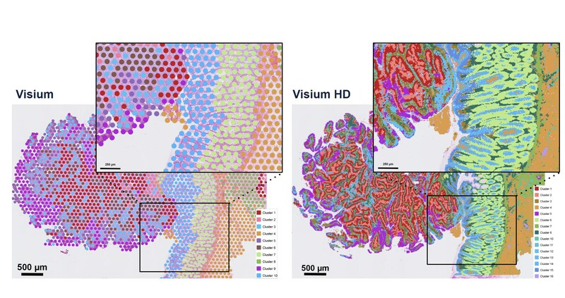

## GEM-X

GEM-X is the next-generation technology architecture from 10x Genomics, improving upon the earlier Next GEM architecture used in previous Chromium assays.

**Assays by GEM-X:**

1. Chromium GEM-X Single Cell Gene Expression v4:
- 3’ whole-transcriptome profiling
- Combines gene expression profiling with cell surface protein detection using feature barcode technology  
  [GEM-X technology](https://www.10xgenomics.com/blog/the-next-generation-of-single-cell-rna-seq-an-introduction-to-gem-x-technology)

  **Feature Barcode Technology** uses oligo-tagged antibodies to measure protein expression on the cell surface alongside transcriptomics data  
  **Combination with Cell surface proteins tagging** using tens to hundreds of antibodies.  
  **Applications** classify immune cell subtypes and states.
2. GEM-X Single Cell Immune Profiling v3:

   Multiomic profiling to map adaptive immune responses. Delivers up to 80% cell capture efficiency and improved pairing of full-length **T- and B-cell** receptor sequences.
- Enhanced Sensitivity and Capture Efficiency:
  - Rare cell types and low-RNA content cells like neutrophils
  - Mapping T-cell and B-cell receptor sequences.
  - Lower Multiplet Rate: Reduces multiplet rates with improved GEM-X microfluidic chips.

**GEM-X SC3’v3 vs v4**

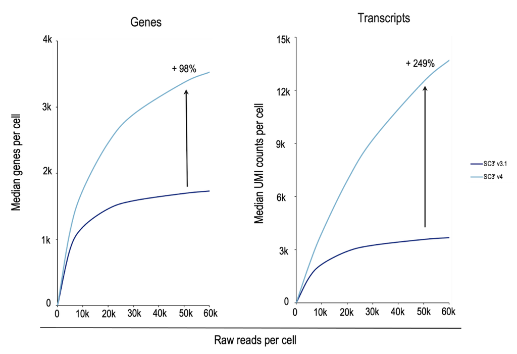

## FLEX

A cutting-edge platform designed to enable single-cell RNA sequencing on previously inaccessible samples. By leveraging fixation technology and a comprehensive **probe-based approach**, FLEX makes it possible to profile gene expression in formaldehyde-fixed, FFPE, and frozen samples.

For challenging sample types  
**Fixed sample or fixation-based**

**Key Features**

1. Works with fresh, frozen, and formalin-fixed, paraffin-embedded (FFPE) samples. Suitable for whole tissues, cell suspensions, and nuclei.
2. Probe-Based RNA Profiling:
- Probe sets targeting predetermined transcript regions.
- Currently available for human (18,082 genes) and mouse (19,059 genes) transcriptomes.
  - [Human probe set](https://www.10xgenomics.com/support/single-cell-gene-expression-flex/documentation/steps/probe-sets/chromium-frp-human-transcriptome-probe-set)
  - [Mouse probe set](https://www.10xgenomics.com/support/single-cell-gene-expression-flex/documentation/steps/probe-sets/chromium-frp-mouse-transcriptome-probe-set)
- Simultaneous Surface Protein Detection: Integrates feature barcode technology for surface protein profiling.
- Sample Fixation and Storage: Samples can be safely stored or transported without compromising data quality. Fixation at the point of collection preserves the biological state.

Compatible with Illumina NextSeq and NovaSeq platforms

[More info at FLEX 10X Genomics](https://www.10xgenomics.com/products/single-cell-gene-expression-flex)

## BEAM (Barcode Enabled Antigen Mapping)

- antigen-specific B- and T-cell clonotypes. Built on the Chromium Single Cell Immune Profiling platform
- **Antigen-Specific Discovery:**
  - BEAM-Ab: Identifies antigen-specific B-cell clonotypes.  
    (BEAM-Ab provides full-length paired B-cell receptor sequences)
  - BEAM-T: Identifies antigen-specific T-cell clonotypes.
  - Comprehensive profiles including full-length paired V(D)J sequences, gene expression, and cell surface proteins.

[BEAM at 10X Genomics](https://www.10xgenomics.com/products/single-cell-barcode-enabled-antigen-mapping)

## Summary Table

| Platform | Purpose | Primary Application | Sample Compatibility | Key Data Output |
| --- | --- | --- | --- | --- |
| **FLEX** | scRNA-seq from fixed tissues | Gene expression and protein detection | Fresh, frozen, fixed | Gene expression and surface protein data |
| **Visium HD** | Spatial transcriptomics | Spatial mapping of gene expression | Fresh frozen, FFPE | Spatial maps of gene expression |
| **GEM-X** | High-throughput scRNA-seq | Single-cell profiling, immune profiling | Fresh tissues | Gene expression, immune receptor sequencing |
| **BEAM** | Antigen-specific B- and T-cell discovery | Antigen screening of immune repertoires | PBMCs, splenocytes, lymph node aspirates | Full-length paired V(D)J sequences, gene expression |

## Single-cell immune profiling technologies

- **BEAM vs Evercode (Parse Bioscience)**

Evercode release event (Boston, May 2024)

[**Evercode link**](https://www.parsebiosciences.com/evercode-bcr-tcr/)

**Single-cell immune profiling technologies by Parse Biosciences and the BEAM technology by 10x Genomics:**

[output not shown]

## proteintech

**MultiPro Fixed Cell Immune Profiling Antibody Cocktail**

[product link](https://www.ptglab.com/products/MultiPro-Human-Fixed-Cell-Immune-Profiling-Antibody-cocktail-G900004.htm)  
[PROT/RNA comparison](https://www.ptglab.com/media/Image-Data-MultiPro-G900004.pdf)

- **Product Overview**: The MultiPro™ cocktail contains 53 antibodies that target a mix of intracellular and surface proteins, plus 5 isotype controls.
- **Cellular Analysis Tool**: Analyzing cellular components in single-cell RNAseq experiments.
- **Compatibility**: Compatible with the 10x Genomics® Chromium® Single Cell Gene Expression Flex product.
- **Dual Detection**: Simultaneous capture of protein and gene expression profiles from the same cell, enhancing the depth of cell state analysis.
- **Intracellular Protein Research**: Marks significant progress in the field by overcoming previous challenges in accessing **intracellular proteins** in single-cell studies.